# A Practical Guide to BERTopic for Transformer-Based Topic Modeling | Towards Data Science

[Machine Learning](https://towardsdatascience.com/category/artificial-intelligence/machine-learning/)

# A Practical Guide to BERTopic for Transformer-Based Topic Modeling

A deep dive into BERTopic’s 6 modules to transform financial news into insightful topics

[Destin Gong](https://towardsdatascience.com/author/destingong/)

May 8, 2025

14 min read

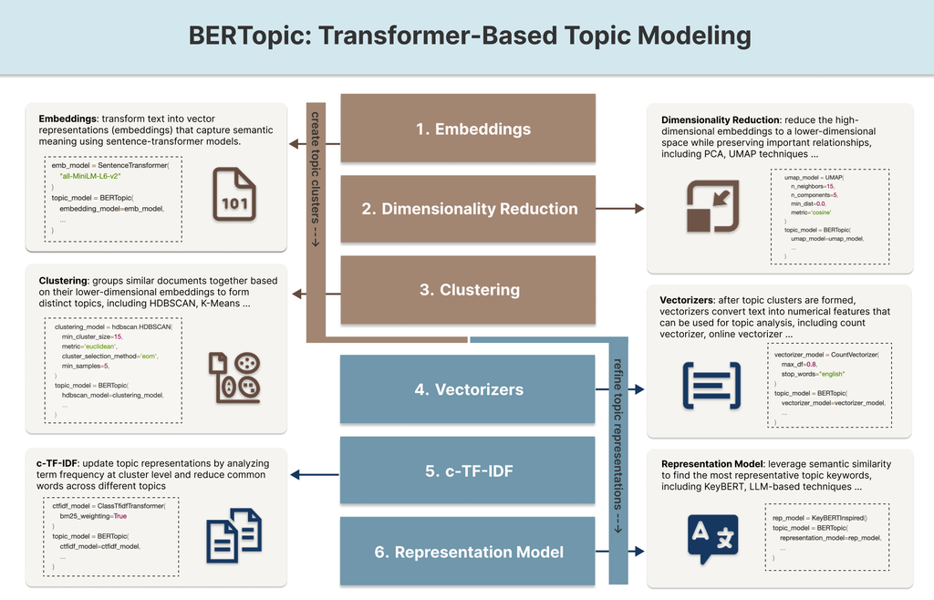

BERTopic: Transformer-Based Topic Modeling (unless otherwise noted, all images are by the author)

Topic modeling has a wide range of use cases in the natural language processing (NLP) domain, such as document tagging, survey analysis, and content organization. It falls under the realm of unsupervised learning technique, making it a very cost-effective technique that reduces the resources required to collect human-annotated data. We will dive deeper into BERTopic, a popular python library for transformer-based topic modeling, to help us process financial news faster and reveal how the trending topics change overtime.  
BERTopic consists of 6 core modules that can be customized to suit different use cases. In this article, we’ll examine, experiment with each module individually and explore how they work together coherently to produce the end results.

At a high level, a typical BERTopic architecture is composed of:

- Embeddings: transform text into vector representations (i.e. embeddings) that capture semantic meaning using sentence-transformer models.
- Dimensionality Reduction: reduce the high-dimensional embeddings to a lower-dimensional space while preserving important relationships, including PCA, UMAP …
- Clustering: group similar documents together based on their embeddings with reduced dimensionality to form distinct topics, including HDBSCAN, K-Means algorithms …
- Vectorizers: after topic clusters are formed, vectorizers convert text into numerical features that can be used for topic analysis, including count vectorizer, online vectorizer …
- c-TF-IDF: calculate importance scores for words within and across topic clusters to identify key terms.
- Representation Model: leverage semantic similarity between the embedding of candidate keywords and the embedding of documents to find the most representative topic keywords, including KeyBERT, LLM-based techniques …

## Project Overview

In this practical application, we will use topic modeling to identify trending topics in Apple financial news. Using NewsAPI, we collect daily top-ranked Apple stock news from Google Search and compile them into a dataset of 250 documents, with each document containing financial news for one specific day. However, this is not the main focus of this article so feel free to replace it with your own dataset. The objective is to demonstrate how to transform raw text documents containing top Google search results into meaningful topic keywords and refine those keywords to be more representative.

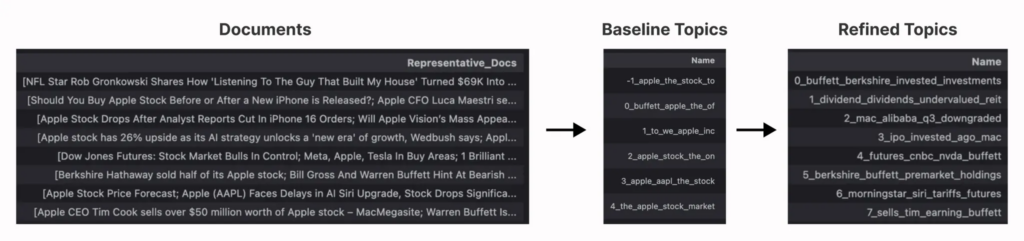

If you prefer a video walkthrough, please check out my YouTube video: **BERTopic Tutorial in 10 Mins | Topic Modeling Applied in Financial News Analysis**.

## BERTopic’s 6 Fundamental Modules

### 1. Embeddings

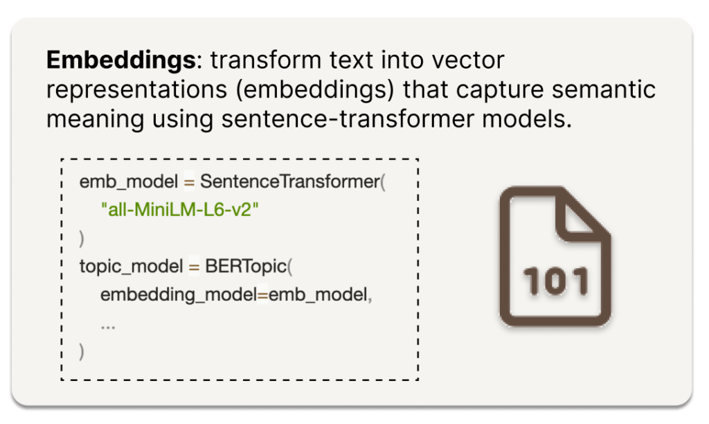

BERTopic uses sentence transformer models as its first building block, converting sentences into dense vector representations (i.e. embeddings) that capture semantic meanings. These models are based on transformer architectures like BERT and are specifically trained to produce high-quality sentence embeddings. We then compute the semantic similarity between sentences using cosine distance between the embeddings. Common models include:

- all-MiniLM-L6-v2: lightweight, fast, good general performance
- BAAI/bge-base-en-v1.5: larger model with strong semantic understanding hence gives much slower training and inference speed.

There are a massive range of pre-trained sentence transformers for you to choose from on the “[Sentence Transformer”](https://www.sbert.net/docs/sentence_transformer/pretrained_models.html) website and [Huggingface model hub](https://huggingface.co/models). We can use a few lines of code to load a sentence transformer model and encode the text sequences into high dimensional numerical embeddings.

```python
from sentence_transformers import SentenceTransformer

# Initialize model
model = SentenceTransformer("all-MiniLM-L6-v2")

# Convert sentences to embeddings
sentences = ["First sentence", "Second sentence"]
embeddings = model.encode(sentences)  # Returns numpy array of embeddings
```

[figure not shown]

We can then feed this sentence transformer to BERTopic pipeline and keep all other modules as the default settings.

```python
from sentence_transformers import SentenceTransformer
from bertopic import BERTopic

emb_minilm = SentenceTransformer("all-MiniLM-L6-v2")
topic_model = BERTopic(
    embedding_model=emb_minilm,
)

topic_model.fit_transform(docs)
topic_model.get_topic_info()
```

As the end result, we get the following topic representation.

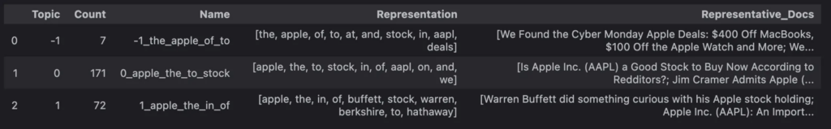

Compared to the more powerful and larger “bge-base-en-v1.5” model, we get the following result which is slightly more meaningful than the smaller “all-MiniLM-L6-v2” model but still leaves large room for improvement.

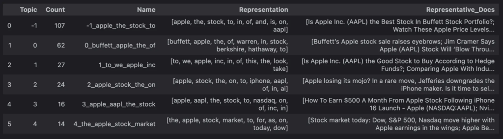

One area for improvement is reducing the dimensionality, because sentence transformers typically results in high-dimensional embeddings. As BERTopic relies on comparing the spatial proximity between embedding space to form meaningful clusters, it is crucial to apply a dimensionality reduction technique to make the embeddings less sparse. Therefore, we are going to introduce various dimensionality reduction techniques in the next section.

### 2. Dimensionality Reduction

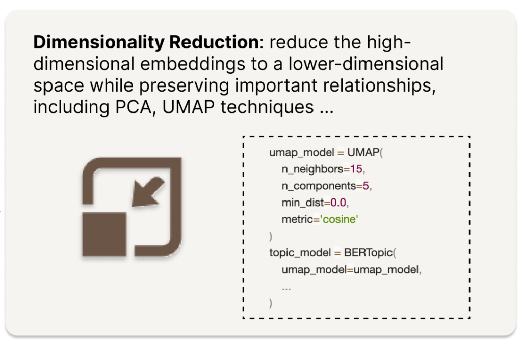

After converting the financial news documents into embeddings, we face the problem of high dimensionality. Since each embedding contains 384 dimensions, the vector space becomes too sparse to create meaningful distance measurement between two vector embeddings. Principal Component Analysis (PCA) and Uniform Manifold Approximation and Projection (UMAP) are common techniques to reduce dimensionalities while preserving the maximum variance in the data. We will look at UMAP, BERTopic’s default dimensionality reduction technique, in more details. It is a non-linear algorithm adopted from topology analysis that seeks diverse structure within the data. It works by extending a radius outwards from each data point and connecting points with its close neighbors. You can dive more into the UMAP visualization on this website “[Understanding UMAP](https://pair-code.github.io/understanding-umap/)“.

**UMAP `n_neighbours` Experimentation**

An important UMAP parameter is `n_neighbours` that controls how UMAP balances local and global structure in the data. Low values of `n_neighbors` will force UMAP to concentrate on local structure, while large values will look at larger neighborhoods of each point.  
The diagram below shows multiple scatterplots demonstrating the effect of different `n_neighbors` values, with each plot visualizing the embeddings in an 2-dimensional space after applying UMAP dimensionality reduction.

With smaller `n_neighbors` values (e.g. n=2, n=5), the plots show more tightly coupled micro clusters, indicating a focus on local structure. As `n_neighbors` increases (towards n=100, n=150), the points form more cohesive global patterns, demonstrating how larger neighborhood sizes help UMAP capture broader relationships in the data.

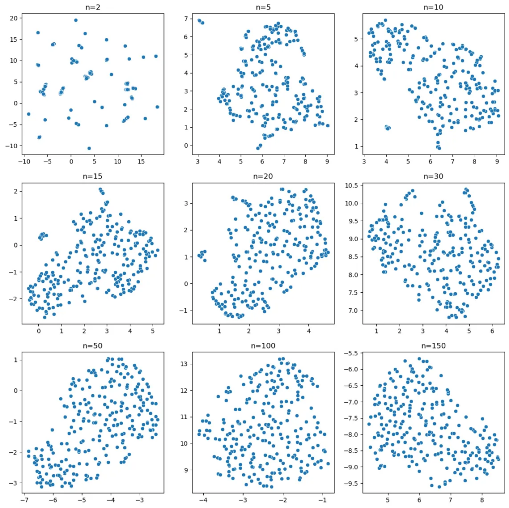

**UMAP `min_dist` Experimentation**

The `min_dist` parameter in UMAP controls how tightly points are allowed to be packed together in the lower dimensional representation. It sets the minimum distance between points in the embedding space. A smaller `min_dist` allows points to be packed very closely together whereas a larger `min_dist` forces points to be more scattered and evenly spread out. The diagram below shows an experimentation on `min_dist` value from 0.0001 to 1 when setting the `n_neighbors=5.` When min_dist is set to smaller values, UMAP emphasizes on preserving local structure whereas larger values transform the embeddings into a circular shape.

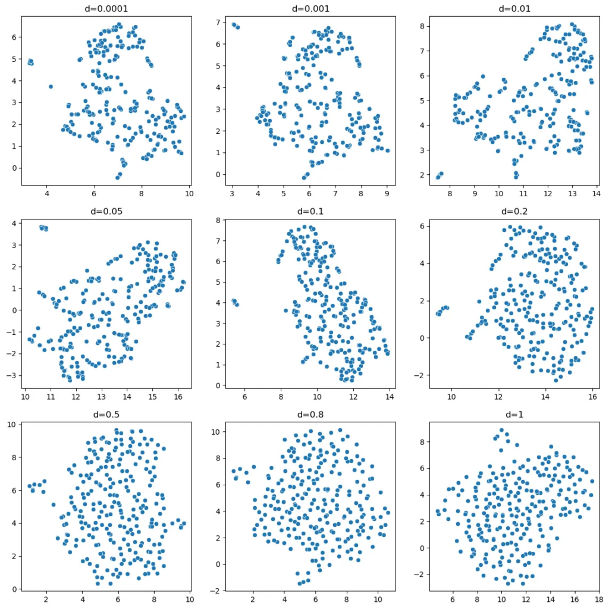

We decide to set `n_neighbors=5` and `min_dist=0.01` based on the hyperparameter tuning results, as it forms more distinct data clusters that are easier for the subsequent clustering model to process.

```python
import umap

UMAP_N = 5
UMAP_DIST = 0.01
umap_model = umap.UMAP(
    n_neighbors=UMAP_N,
    min_dist=UMAP_DIST,
    random_state=0
)
```